# Project Title: Email Spam Detection

# INTRODUCTION

This project aims to develop a machine learning-based system capable of identifying and classifying spam messages, including emails and SMS, to reduce unwanted communications. By analyzing various textual features, the model learns to distinguish between spam (unwanted) and ham (legitimate) messages.

```python
## importing the necessary libraries
import pandas as pd
import numpy as np
import matplotlib.pyplot as plt
import seaborn as sns
```

```python
##Loading the Spam dataset
data =pd.read_csv('/content/spam (1).csv', encoding='latin-1')
data
```

|  | v1 | v2 | Unnamed: 2 | Unnamed: 3 | Unnamed: 4 |
| --- | --- | --- | --- | --- | --- |
| 0 | ham | Go until jurong point, crazy.. Available only ... | NaN | NaN | NaN |
| 1 | ham | Ok lar... Joking wif u oni... | NaN | NaN | NaN |
| 2 | spam | Free entry in 2 a wkly comp to win FA Cup fina... | NaN | NaN | NaN |
| 3 | ham | U dun say so early hor... U c already then say... | NaN | NaN | NaN |
| 4 | ham | Nah I don't think he goes to usf, he lives aro... | NaN | NaN | NaN |
| ... | ... | ... | ... | ... | ... |
| 5567 | spam | This is the 2nd time we have tried 2 contact u... | NaN | NaN | NaN |
| 5568 | ham | Will Ì_ b going to esplanade fr home? | NaN | NaN | NaN |
| 5569 | ham | Pity, * was in mood for that. So...any other s... | NaN | NaN | NaN |
| 5570 | ham | The guy did some bitching but I acted like i'd... | NaN | NaN | NaN |
| 5571 | ham | Rofl. Its true to its name | NaN | NaN | NaN |

5572 rows × 5 columns

# Cleaning the dataset

```python
## To remove unnecessary columns
data.drop(["Unnamed: 2", "Unnamed: 3", "Unnamed: 4"], axis=1, inplace=True)
data
```

|  | v1 | v2 |
| --- | --- | --- |
| 0 | ham | Go until jurong point, crazy.. Available only ... |
| 1 | ham | Ok lar... Joking wif u oni... |
| 2 | spam | Free entry in 2 a wkly comp to win FA Cup fina... |
| 3 | ham | U dun say so early hor... U c already then say... |
| 4 | ham | Nah I don't think he goes to usf, he lives aro... |
| ... | ... | ... |
| 5567 | spam | This is the 2nd time we have tried 2 contact u... |
| 5568 | ham | Will Ì_ b going to esplanade fr home? |
| 5569 | ham | Pity, * was in mood for that. So...any other s... |
| 5570 | ham | The guy did some bitching but I acted like i'd... |
| 5571 | ham | Rofl. Its true to its name |

5572 rows × 2 columns

```python
## Selecting and renaming relevant columns

data = data[['v1', 'v2']]
data.rename(columns={'v1': 'label', 'v2': 'message'}, inplace=True)
data.head()
```

|  | label | message |
| --- | --- | --- |
| 0 | ham | Go until jurong point, crazy.. Available only ... |
| 1 | ham | Ok lar... Joking wif u oni... |
| 2 | spam | Free entry in 2 a wkly comp to win FA Cup fina... |
| 3 | ham | U dun say so early hor... U c already then say... |
| 4 | ham | Nah I don't think he goes to usf, he lives aro... |

# Understanding the dataset

```python
data.info()
```

```
<class 'pandas.core.frame.DataFrame'>
RangeIndex: 5572 entries, 0 to 5571
Data columns (total 2 columns):
 #   Column   Non-Null Count  Dtype
---  ------   --------------  -----
 0   label    5572 non-null   object
 1   message  5572 non-null   object
dtypes: object(2)
memory usage: 87.2+ KB
```

```python
data.describe()
```

|  | label | message |
| --- | --- | --- |
| count | 5572 | 5572 |
| unique | 2 | 5169 |
| top | ham | Sorry, I'll call later |
| freq | 4825 | 30 |

```python
data.isnull().sum()
```

|  | 0 |
| --- | --- |
| label | 0 |
| message | 0 |

**dtype:** int64

```python
## Checking for duplicate records in the dataset and dropping them

data.duplicated().sum()
```

```
403
```

```python
data.drop_duplicates(inplace= True)
```

```python
data.duplicated().sum()
```

```
0
```

```python
## Mapping labels to binary (ham: 0, spam: 1)
data['label'] = data['label'].map({'ham': 0, 'spam': 1})
```

```python
## Display first few rows
data.head()
```

|  | label | message |
| --- | --- | --- |
| 0 | 0 | Go until jurong point, crazy.. Available only ... |
| 1 | 0 | Ok lar... Joking wif u oni... |
| 2 | 1 | Free entry in 2 a wkly comp to win FA Cup fina... |
| 3 | 0 | U dun say so early hor... U c already then say... |
| 4 | 0 | Nah I don't think he goes to usf, he lives aro... |

```python
## Check dataset balance
print(data['label'].value_counts())
```

```
label
0    4516
1     653
Name: count, dtype: int64
```

There is class imbalance among the data

# Exploratory Data Analysis (EDA) : Performing EDA to understand the dataset.

```python
## Percentage distribution: This is to reveal whether the dataset is imbalanced which may affect model performance.

Label_counts = data['label'].value_counts()
Label_percentages = Label_counts / len(data) * 100
print(Label_percentages)
```

```
label
0    87.366996
1    12.633004
Name: count, dtype: float64
```

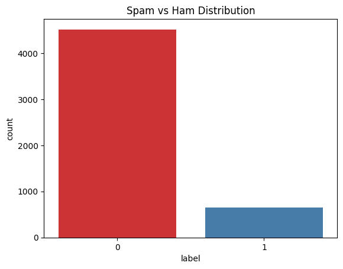

```python
sns.countplot(x='label', data=data, palette='Set1')
plt.title('Spam vs Ham Distribution')
plt.show()
```

This counplot explains that the count of HAM -0 is has more messages of over 4000 than SPAM- 1 that has less than 1000 messages.

```python
# Message length analysis
data['message_length'] = data['message'].apply(len)
```

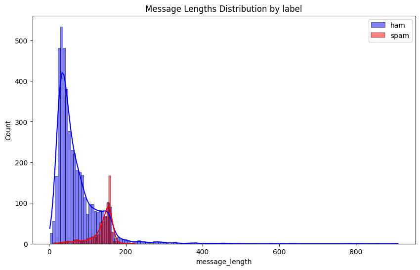

```python
# Plot distribution of message lengths
plt.figure(figsize=(10, 6))
sns.histplot(data [data ['label'] ==0]['message_length'], color= 'blue', kde=True, label= 'ham')
sns.histplot(data [data ['label'] ==1]['message_length'], color= 'red', kde=True, label= 'spam')
plt.legend()
plt.title('Message Lengths Distribution by label')
plt.show()
```

The histogram displays the frequency of messages based on their length. The two distributions shown are: Blue (Ham messages): Represents the message length distribution for non-spam messages. Red (Spam messages): Represents the message length distribution for spam messages.

```python
## Exploring Common Words in spam and ham
from collections import Counter
from wordcloud import WordCloud
```

```python
def generate_wordcloud(text, title):
    # Convert all elements of the Series to strings before joining
    text = text.astype(str)
    wordcloud = WordCloud(width=800, height=400, background_color='white').generate(' '.join(text))
    plt.figure(figsize=(10, 5))
    plt.imshow(wordcloud, interpolation='bilinear')
    plt.title(title, fontsize = 16)
    plt.axis('off')
    plt.show()
```

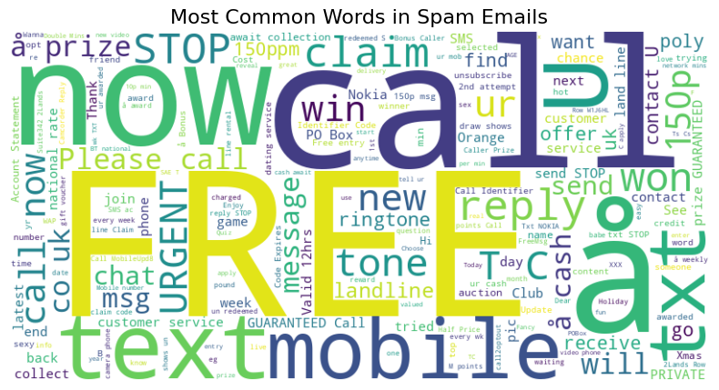

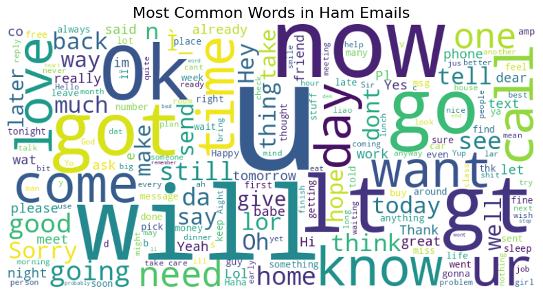

```python
spam_words = data[data['label'] == 1]['message']  # Filter for spam (label 1)
ham_words = data[data['label'] == 0]['message']  # Filter for ham (label 0)

generate_wordcloud(spam_words, 'Most Common Words in Spam Emails')
generate_wordcloud(ham_words, 'Most Common Words in Ham Emails')
```

# Data Preprocessing : prepare the text data for machine learning

**Preprocessing Steps**

```python
## impoeting the needed libraries

import string
from sklearn.feature_extraction.text import TfidfVectorizer
```

```python
# Importing nltk
import nltk
```

```python
# Downloading stopwords dataset
nltk.download('stopwords')
from nltk.corpus import stopwords
```

```python
## Remove punctuation and stopwords
def preprocess_text(text):
    text = text.lower()
    text = ''.join([char for char in text if char not in string.punctuation])
    words = text.split()
    stop_words = stopwords.words('english')
    return ' '.join([word for word in words if word not in stop_words])
```

```python
## Apply preprocessing
data['cleaned_message'] = data['message'].apply(preprocess_text)
```

```python
## Transform text using TF-IDF
vectorizer = TfidfVectorizer(max_features=5000)
X = vectorizer.fit_transform(data['cleaned_message'])
y = data['label']
```

```python
## Analyzing how the length of the emails varies between spam and ham
data['length'] = data['cleaned_message'].apply(len)
```

```python
## Comparing average text length for spam vs ham
print(data.groupby('label')['length'].describe())
```

```
        count        mean        std   min   25%    50%    75%    max
label
0      4516.0   45.098760  36.649723   0.0  21.0   34.0   59.0  516.0
1       653.0  106.355283  26.654331  12.0  96.0  112.0  124.0  159.0
```

```python
categorical_df = data.select_dtypes(include=['object'])
categorical_df.head()
```

|  | message | cleaned_message |
| --- | --- | --- |
| 0 | Go until jurong point, crazy.. Available only ... | go jurong point crazy available bugis n great ... |
| 1 | Ok lar... Joking wif u oni... | ok lar joking wif u oni |
| 2 | Free entry in 2 a wkly comp to win FA Cup fina... | free entry 2 wkly comp win fa cup final tkts 2... |
| 3 | U dun say so early hor... U c already then say... | u dun say early hor u c already say |
| 4 | Nah I don't think he goes to usf, he lives aro... | nah dont think goes usf lives around though |

```python
cat_df = categorical_df.columns
cat_df = list(cat_df)
cat_df
```

```
['message', 'cleaned_message']
```

```python
### Changing my categorical data to numerical data
from sklearn.preprocessing import LabelEncoder
```

```python
Lab_enc = LabelEncoder()

for i in cat_df:
  data[i] = Lab_enc.fit_transform(data[i])
```

```python
data.head()
```

|  | label | message | message_length | cleaned_message | length |
| --- | --- | --- | --- | --- | --- |
| 0 | 0 | 1079 | 111 | 1260 | 82 |
| 1 | 0 | 3101 | 29 | 3013 | 23 |
| 2 | 1 | 1000 | 155 | 1124 | 135 |
| 3 | 0 | 4088 | 49 | 4266 | 35 |
| 4 | 0 | 2757 | 61 | 2733 | 43 |

```python
## Sorting class imbalance

## Check dataset balance
print(data['label'].value_counts())
```

```
label
0    4516
1     653
Name: count, dtype: int64
```

```python
from imblearn.over_sampling import RandomOverSampler
```

```python
sample = data.groupby('label').sample(frac=0.2, random_state=42) # Sample 20% from each label
sample.head()
```

|  | label | message | message_length | cleaned_message | length |
| --- | --- | --- | --- | --- | --- |
| 1883 | 0 | 592 | 128 | 589 | 60 |
| 1709 | 0 | 4104 | 59 | 4300 | 42 |
| 4919 | 0 | 1042 | 48 | 1194 | 37 |
| 1297 | 0 | 2434 | 38 | 2219 | 16 |
| 3948 | 0 | 1215 | 83 | 1841 | 49 |

```python
sample.shape
```

```
(1034, 5)
```

```python
sample['label'].value_counts()
```

| label | count |
| --- | --- |
| 0 | 903 |
| 1 | 131 |

**dtype:** int64

```python
ros = RandomOverSampler(random_state=12)
```

```python
x = sample.drop('label', axis=1)
y = sample['label']
```

```python
x_ros, y_ros = ros.fit_resample(x,y)

x_ros.shape, y_ros.shape
```

```
((1806, 4), (1806,))
```

```python
y_ros.value_counts()
```

| label | count |
| --- | --- |
| 0 | 903 |
| 1 | 903 |

**dtype:** int64

```python
print(data['cleaned_message'].head())  # Check the first few entries
print(data[data['label'] == 1]['cleaned_message'].head())  # Check spam
print(data[data['label'] == 0]['cleaned_message'].head())  # Check ham
```

```
0    1260
1    3013
2    1124
3    4266
4    2733
Name: cleaned_message, dtype: int64
2     1124
5     1155
8     4737
9     2668
11    3672
Name: cleaned_message, dtype: int64
0    1260
1    3013
3    4266
4    2733
6    1015
Name: cleaned_message, dtype: int64
```

```python
## The label column has been previously converted into numerical values: i.e ham → 0, spam → 1

data.head()
```

|  | label | message | message_length | cleaned_message | length |
| --- | --- | --- | --- | --- | --- |
| 0 | 0 | 1079 | 111 | 1260 | 82 |
| 1 | 0 | 3101 | 29 | 3013 | 23 |
| 2 | 1 | 1000 | 155 | 1124 | 135 |
| 3 | 0 | 4088 | 49 | 4266 | 35 |
| 4 | 0 | 2757 | 61 | 2733 | 43 |

```python
# Features (X) and target (y)
X = data['cleaned_message']
y = data['label']
```

**Model Selection and Training** : Train and evaluate multiple models for performance.

**Split Data**

```python
## importing the needed library
from sklearn.model_selection import train_test_split
```

```python
## Train-test split
X_train, X_test, y_train, y_test = train_test_split(x_ros, y_ros, test_size=0.2, random_state=42)
```

```python
## The number of 80% of training date
len(data['message']) * 0.8
```

```
4135.2
```

```python
## The number of 80% of training date
len(data['message']) * 0.2
```

```
1033.8
```

```python
# Output shapes
print("Training features shape:", X_train.shape)
print("Test features shape:", X_test.shape)
print("Training target shape:", y_train.shape)
print("Test target shape:", y_test.shape)
```

```
Training features shape: (1444, 4)
Test features shape: (362, 4)
Training target shape: (1444,)
Test target shape: (362,)
```

**Train a Logistic Regression Model**

```python
## importing the needed library
from sklearn.linear_model import LogisticRegression
from sklearn.metrics import accuracy_score, classification_report, confusion_matrix
```

```python
## Train logistic regression
lr_model = LogisticRegression()
lr_model.fit(X_train, y_train)
```

```
LogisticRegression()
```

```python
lr_model.score(X_train, y_train), lr_model.score(X_test, y_test)
```

```
(0.8822714681440443, 0.8535911602209945)
```

```python
accuracy_score(y_test, lr_model.predict(X_test))
```

```
0.8535911602209945
```

```python
lr_cn = confusion_matrix(y_test, lr_model.predict(X_test))
lr_cn
```

```
array([[160,  21],
       [ 32, 149]])
```

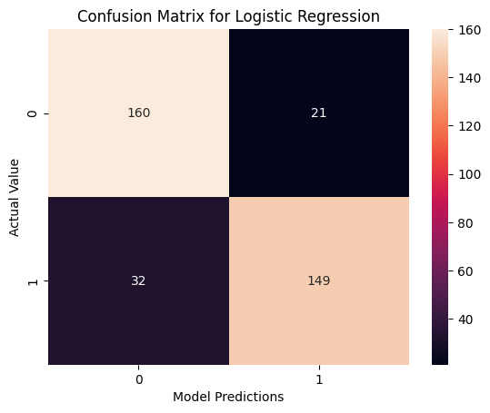

```python
sns.heatmap(lr_cn, annot = True, fmt = "g")#fmt = value format, annot = show value, cmap = style)
plt.ylabel("Actual Value")
plt.xlabel("Model Predictions")
plt.title("Confusion Matrix for Logistic Regression")
plt.show()
```

**Interpretation:**

**True Negative (TN):** 160 - The model correctly predicted 160 emails as "ham."

**False Positive (FP)**: 21 - The model incorrectly predicted 21 "ham" emails as "spam." (Type I error)

**False Negative (FN)**: 32 - The model incorrectly predicted 32 "spam" emails as "ham." (Type II error)

**True Positive (TP):** 149 - The model correctly predicted 149 emails as "spam."

**Overall Performance:**

Based on these numbers, we can see that the model is performing reasonably well. It's correctly classifying a majority of both "ham" and "spam" emails. However, there are some misclassifications:

**False Positives:** 21 legitimate emails were wrongly classified as spam. This could lead to users missing important messages.

**False Negatives: **32 spam emails were wrongly classified as ham. This could expose users to unwanted or potentially harmful content.

**To achieve even better results, i will be employing other models**

```python
from sklearn.feature_extraction.text import TfidfVectorizer
from sklearn.model_selection import train_test_split
from sklearn.metrics import classification_report, accuracy_score
from sklearn.naive_bayes import MultinomialNB
from sklearn.svm import SVC
from sklearn.ensemble import RandomForestClassifier
from sklearn.tree import DecisionTreeClassifier
```

**1. Multinomial Naive Bayes**

```python
# Train Multinomial Naive Bayes
nb_model = MultinomialNB()
nb_model.fit(X_train, y_train)
```

```
MultinomialNB()
```

```python
nb_model.score(X_train, y_train), nb_model.score(X_test, y_test)
```

```
(0.6835180055401662, 0.6823204419889503)
```

```python
accuracy_score(y_test, nb_model.predict(X_test))
```

```
0.6823204419889503
```

```python
nb_cn = confusion_matrix(y_test, nb_model.predict(X_test))
nb_cn
```

```
array([[125,  56],
       [ 59, 122]])
```

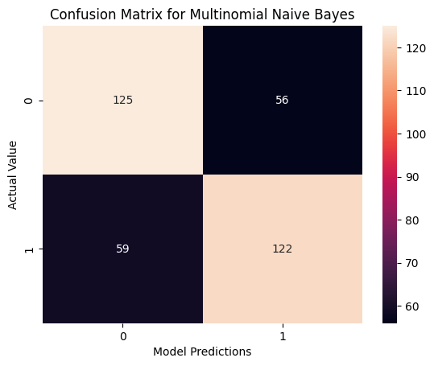

```python
sns.heatmap(nb_cn, annot = True, fmt = "g")#fmt = value format, annot = show value, cmap = style)
plt.ylabel("Actual Value")
plt.xlabel("Model Predictions")
plt.title("Confusion Matrix for Multinomial Naive Bayes")
plt.show()
```

**Interpretation:**

**True Negative (TN):** 125 - The model correctly predicted 125 emails as "ham."

**False Positive (FP):** 56 - The model incorrectly predicted 56 "ham" emails as "spam." (Type I error)

**False Negative (FN):** 59 - The model incorrectly predicted 59 "spam" emails as "ham." (Type II error)

**True Positive (TP):** 122 - The model correctly predicted 122 emails as "spam."

**Overall Performance:**

Compared to the previous model, this Multinomial Naive Bayes model seems to have a higher number of misclassifications.

**False Positives: **56 legitimate emails were wrongly classified as spam, which is a significant increase compared to the previous model's 21. This could be a concern as it might lead to users missing important messages.

**2. Support Vector Machine (SVM)**

```python
# Train SVM
svm_model = SVC(kernel='linear', C=1.0)
svm_model.fit(X_train, y_train)
```

```
SVC(kernel='linear')
```

```python
svm_model.score(X_train, y_train), svm_model.score(X_test, y_test)
```

```
(0.8732686980609419, 0.8480662983425414)
```

```python
accuracy_score(y_test, svm_model.predict(X_test))
```

```
0.8480662983425414
```

```python
svm_cn = confusion_matrix(y_test, svm_model.predict(X_test))
svm_cn
```

```
array([[154,  27],
       [ 28, 153]])
```

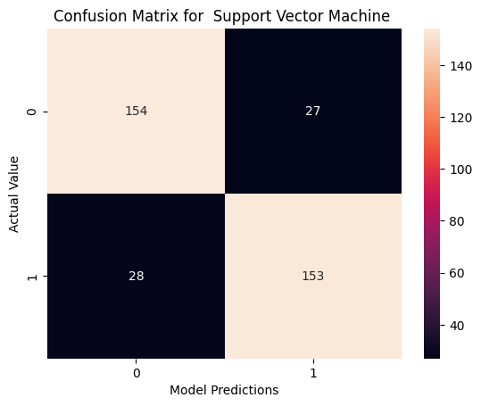

```python
sns.heatmap(svm_cn, annot = True, fmt = "g")#fmt = value format, annot = show value, cmap = style)
plt.ylabel("Actual Value")
plt.xlabel("Model Predictions")
plt.title("Confusion Matrix for Support Vector Machine ")
plt.show()
```

**Interpretation:**

**True Negative (TN):** 154 - The model correctly predicted 154 emails as "ham."

**False Positive (FP):** 27 - The model incorrectly predicted 27 "ham" emails as "spam." (Type I error)

**False Negative (FN):** 28 - The model incorrectly predicted 28 "spam" emails as "ham." (Type II error)

**True Positive (TP):** 153 - The model correctly predicted 153 emails as "spam."

**Overall Performance:**

The SVM model demonstrates a good balance between correctly identifying ham and spam emails. Here's a breakdown:

**False Positives:** 27 legitimate emails were wrongly classified as spam. While not ideal, this number is relatively low compared to the Multinomial Naive Bayes model (which had 56 FPs).

**False Negatives:** 28 spam emails were wrongly classified as ham. This is also a relatively low number and comparable to the previous models.

**3. Random Forest**

```python
# Train Random Forest
rf_model = RandomForestClassifier(n_estimators=100, random_state=42)
rf_model.fit(X_train, y_train)
```

```
RandomForestClassifier(random_state=42)
```

```python
rf_model.score(X_train, y_train), rf_model.score(X_test, y_test)
```

```
(1.0, 0.9834254143646409)
```

```python
accuracy_score(y_test, rf_model.predict(X_test))
```

```
0.9834254143646409
```

```python
rf_cn = confusion_matrix(y_test, rf_model.predict(X_test))
rf_cn
```

```
array([[175,   6],
       [  0, 181]])
```

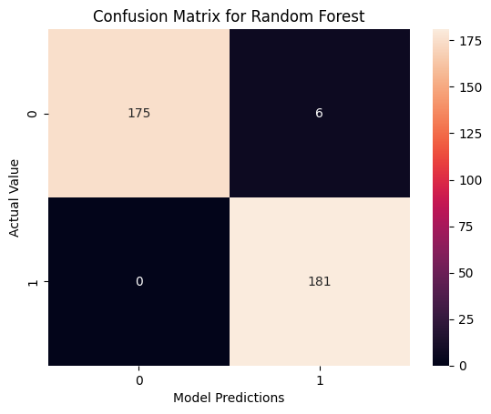

```python
sns.heatmap(rf_cn, annot = True, fmt = "g")#fmt = value format, annot = show value, cmap = style)
plt.ylabel("Actual Value")
plt.xlabel("Model Predictions")
plt.title("Confusion Matrix for Random Forest")
plt.show()
```

**Interpretation:**

**True Negative (TN):** 175 - The model correctly predicted 175 emails as "ham."

**False Positive (FP):** 6 - The model incorrectly predicted 6 "ham" emails as "spam." (Type I error)

**False Negative (FN):** 0 - The model incorrectly predicted 0 "spam" emails as "ham." (Type II error)

**True Positive (TP):** 181 - The model correctly predicted 181 emails as "spam."

**Overall Performance:**

The Random Forest model demonstrates exceptional performance based on this confusion matrix.

**Extremely Low False Negatives:** The model did not misclassify any spam emails as ham (FN = 0). This is a highly desirable outcome in spam detection as it ensures no spam slips through the filter.

**Low False Positives:** Only 6 legitimate emails were wrongly classified as spam, which is a very low number. This suggests the model maintains a high level of accuracy while minimizing the risk of misclassifying legitimate emails.

**Comparison with other models:**

Compared to all previous models: The Random Forest model significantly outperforms all others in terms of both False Positives and False Negatives. It achieves a near-perfect balance, demonstrating excellent accuracy and minimizing both types of errors.

**4. Decision Tree Classifier**

```python
# Train Decision Tree
dt_model = DecisionTreeClassifier(random_state=42)
dt_model.fit(X_train, y_train)
```

```
DecisionTreeClassifier(random_state=42)
```

```python
dt_model.score(X_train, y_train), dt_model.score(X_test, y_test)
```

```
(1.0, 0.9806629834254144)
```

```python
accuracy_score(y_test, dt_model.predict(X_test))
```

```
0.9806629834254144
```

```python
dt_cn = confusion_matrix(y_test, rf_model.predict(X_test))
dt_cn
```

```
array([[175,   6],
       [  0, 181]])
```

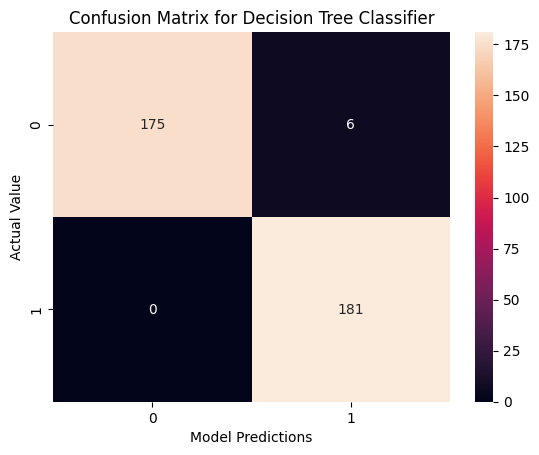

```python
sns.heatmap(dt_cn, annot = True, fmt = "g")#fmt = value format, annot = show value, cmap = style)
plt.ylabel("Actual Value")
plt.xlabel("Model Predictions")
plt.title("Confusion Matrix for Decision Tree Classifier")
plt.show()
```

**Interpretation:**

**True Negative (TN):** 175 - The model correctly predicted 175 emails as "ham."

**True Positive (TP):** 181 - The model correctly predicted 181 emails as "spam."

**Overall Performance:**

The Decision Tree Classifier demonstrates exceptional performance, similar to the Random Forest model, based on this confusion matrix.

**Comparison with other models:**

**Compared to all previous models:** The Decision Tree Classifier, like the Random Forest, significantly outperforms other models like Logistic Regression, Multinomial Naive Bayes, and SVM in terms of both False Positives and False Negatives. It achieves a near-perfect balance, demonstrating excellent accuracy and minimizing both types of errors.

# Hyperparameter Tuning

```python
## Importing the necessary libraries:

from sklearn.tree import DecisionTreeClassifier
from sklearn.model_selection import GridSearchCV
```

```python
## Defining the parameter grind

param_grid = {
       'criterion': ['gini', 'entropy'],  # Function to measure the quality of a split
       'max_depth': [None, 10, 20, 30],  # Maximum depth of the tree
       'min_samples_split': [2, 5, 10],  # Minimum number of samples required to split an internal node
       'min_samples_leaf': [1, 2, 4],  # Minimum number of samples required to be at a leaf node
       'max_features': ['auto', 'sqrt', 'log2'],  # Number of features to consider when looking for the best split
   }

dt_model = DecisionTreeClassifier()
grid_search = GridSearchCV(estimator=dt_model, param_grid=param_grid,
                              scoring='accuracy', cv=5, n_jobs=-1, verbose=2)

grid_search.fit(X_train, y_train)
```

```
Fitting 5 folds for each of 216 candidates, totalling 1080 fits
```

[output not shown]

[output cut: 15 more lines]

[output not shown]

```
GridSearchCV(cv=5, estimator=DecisionTreeClassifier(), n_jobs=-1,
             param_grid={'criterion': ['gini', 'entropy'],
                         'max_depth': [None, 10, 20, 30],
                         'max_features': ['auto', 'sqrt', 'log2'],
                         'min_samples_leaf': [1, 2, 4],
                         'min_samples_split': [2, 5, 10]},
             scoring='accuracy', verbose=2)
```

```python
dt_model = DecisionTreeClassifier()

dt_model.fit(X_train, y_train)
dt_model.pred = dt_model.predict(X_test)
dt_model.score(X_train, y_train), dt_model.score(X_test, y_test)
```

```
(1.0, 0.9779005524861878)
```

```python
accuracy_score(y_test, dt_model.predict(X_test))
```

```
0.9779005524861878
```

```python
dt_cn = confusion_matrix(y_test, rf_model.predict(X_test))
dt_cn
```

```
array([[175,   6],
       [  0, 181]])
```

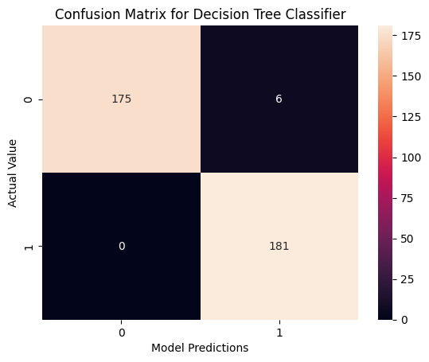

```python
sns.heatmap(dt_cn, annot = True, fmt = "g")#fmt = value format, annot = show value, cmap = style)
plt.ylabel("Actual Value")
plt.xlabel("Model Predictions")
plt.title("Confusion Matrix for Decision Tree Classifier")
plt.show()
```

** Overall Conclusion:**

# Cross Validation of the Model

```python
## Using cross_val_score:

## importing the necessary library
from sklearn.model_selection import cross_val_score


 # 5-fold cross-validation
cv_scores = cross_val_score(dt_model, X_train, y_train, cv=5, scoring='accuracy')

print("Cross-validation scores:", cv_scores)
print("Average cross-validation score:", cv_scores.mean())
```

```
Cross-validation scores: [0.94809689 0.96193772 0.94463668 0.95847751 0.96180556]
Average cross-validation score: 0.9549908688965782
```

**Interpretation:**

**Individual Scores:** The list [0.94809689 0.96193772 0.94463668 0.95847751 0.96180556] represents the performance of the model on each of the 5 folds during cross-validation. These scores are likely accuracy scores (assuming scoring='accuracy' in the cross-validation code was used), indicating the percentage of correctly classified instances in each fold.

**Average Score:** The average cross-validation score of 0.9549908688965782 represents the overall performance of the model, estimated by averaging the scores across all folds. This score provides a more robust estimate of how well the model is likely to perform on unseen data compared to evaluating on a single train-test split.

**Meaning of the Score:**

An average cross-validation score of approximately 0.955 (or 95.5%) suggests that the model is performing very well. It indicates that, on average, the model correctly classifies about 95.5% of the instances in the dataset. This is generally considered a high accuracy score, implying that the model has learned the underlying patterns in the data effectively.

**Confidence in the Score:**

The individual scores across the folds provide insights into the variability of the model's performance. In this case, the scores range from 0.944 to 0.962, indicating relatively low variability. This suggests that the model's performance is consistent across different subsets of the data, further increasing confidence in the average score.